# O15-task macBP gamma & sniff-locked spectrograms

## 6. Time-resolved gamma (FOOOF over epochs, by sniff type)

**Methods.** For each session’s `bestMac` and **each sniff category (start / free / confirm)**, Morlet power (5–58 Hz, 100 linear freqs) was computed on the noise-clean sniffs of that type, then averaged over trials and into ten sequential **250 ms windows** spanning −500…+2000 ms. FOOOF (same settings as the overall channel fit) was applied to each window; the largest 30–58 Hz periodic peak per window is recorded in `O15Task_gammaEpochs.csv` (column `locking`). There are many more *free* sniffs than *start*/*confirm* sniffs — that is expected and fine. “Channel-centered” = each window’s gamma peak frequency minus that channel’s overall gamma peak (§3).

### 6.1 Example gamma time-progression (one session per group, all three sniff types)

**250623_Dupi_NMH_KS_1 (DupiS1)**

*start-sniff:*

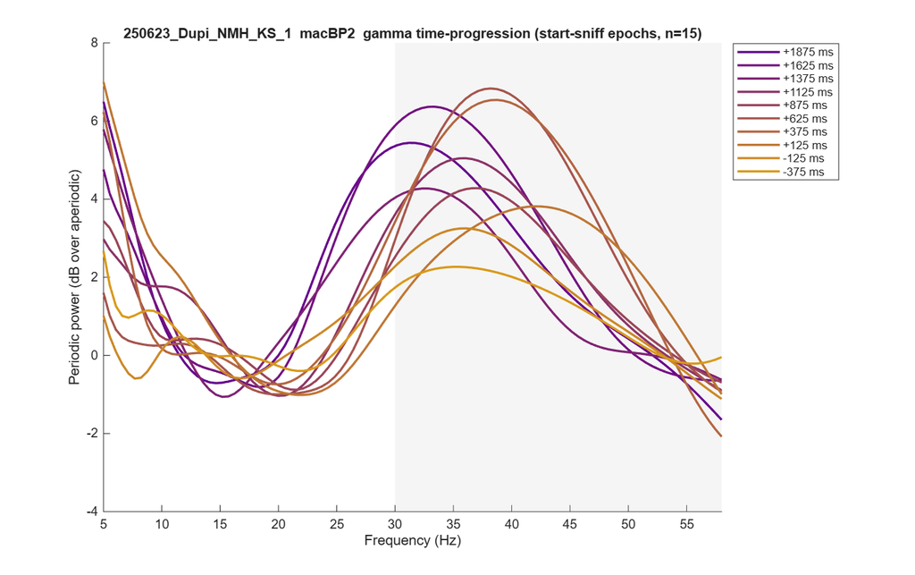

*free-sniff:*

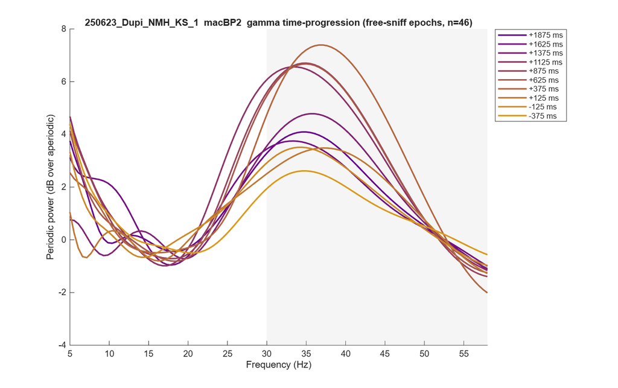

*confirm-sniff:*

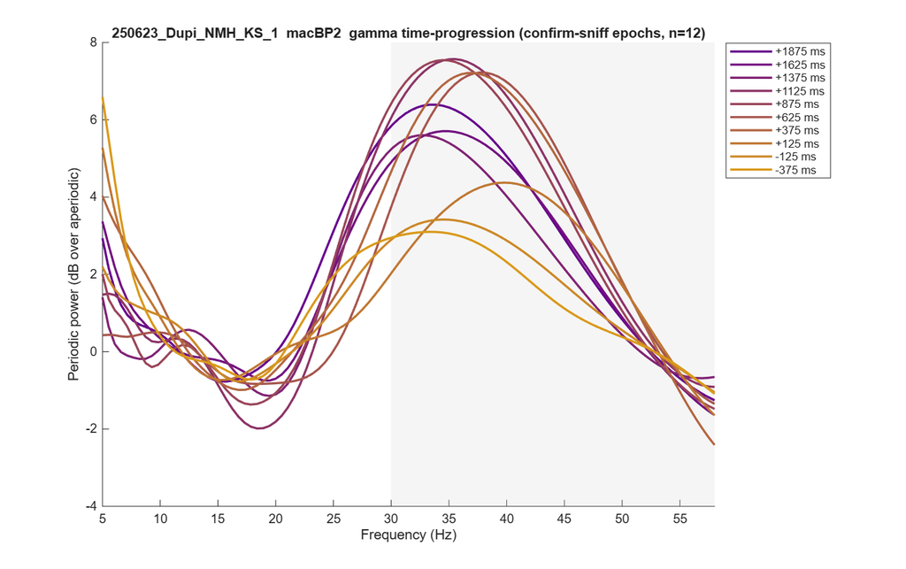

**250623_Dupi_NMH_KS_2 (DupiS2)**

*start-sniff:*

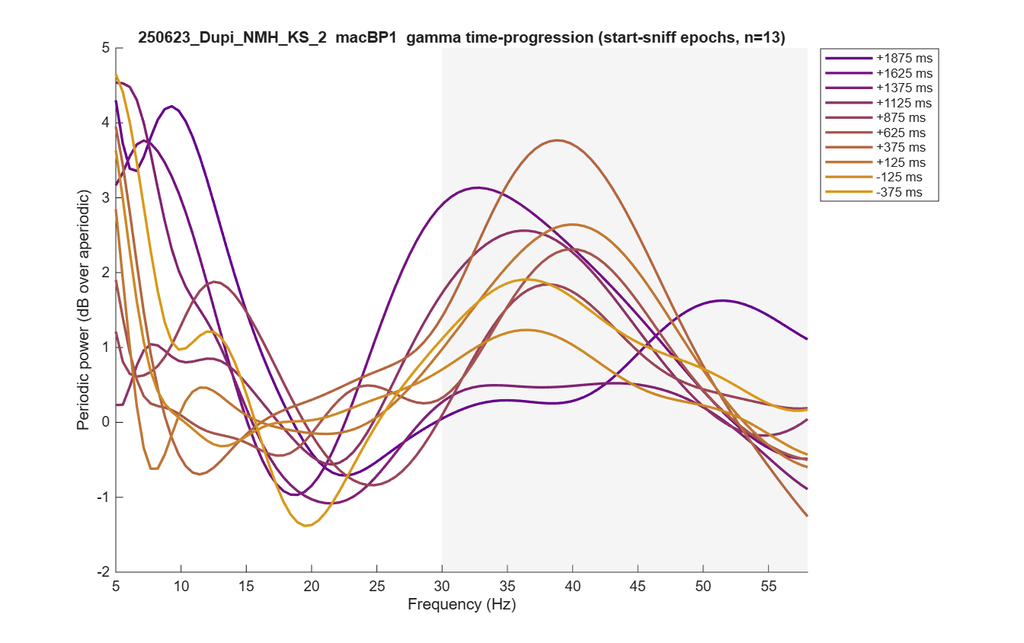

*free-sniff:*

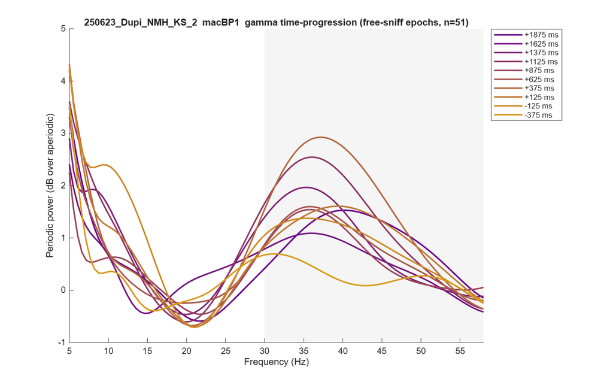

*confirm-sniff:*

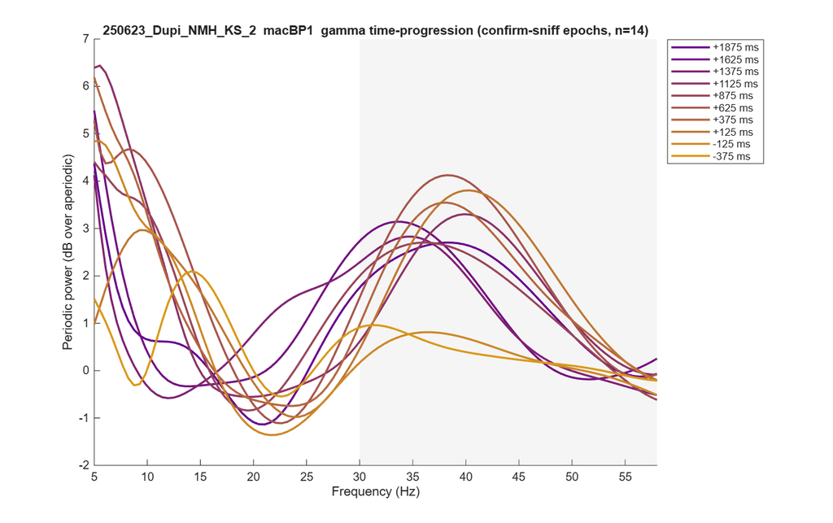

*DupiS3: none*

**250225_OBE_NWU_AS_4 (Control)**

*start-sniff:*

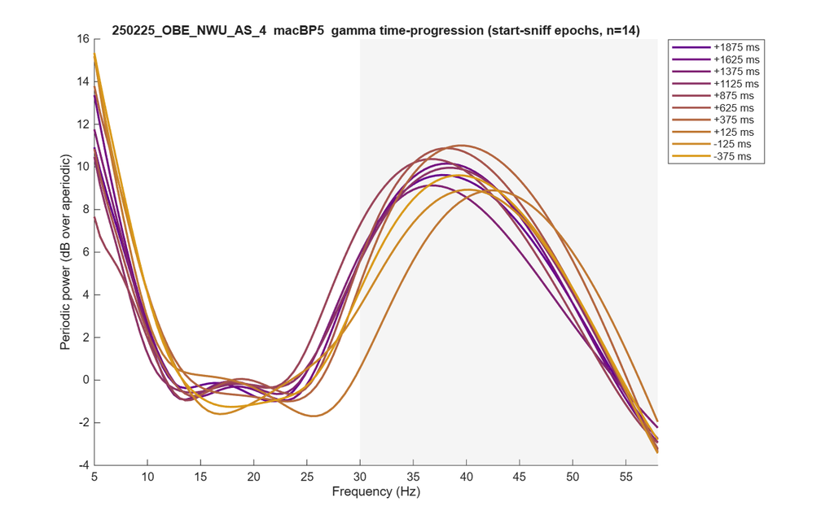

*free-sniff:*

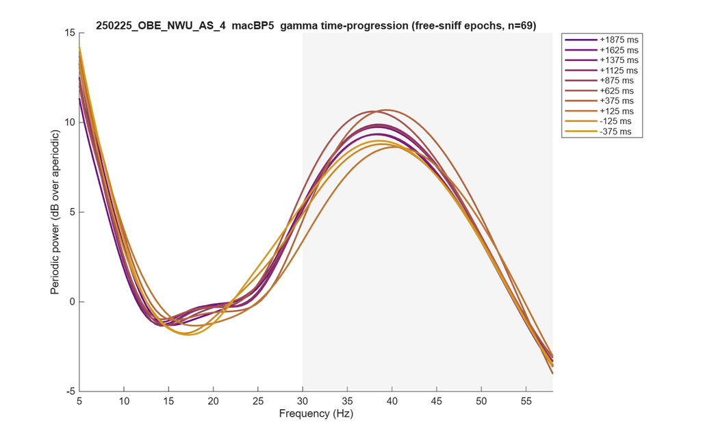

*confirm-sniff:*

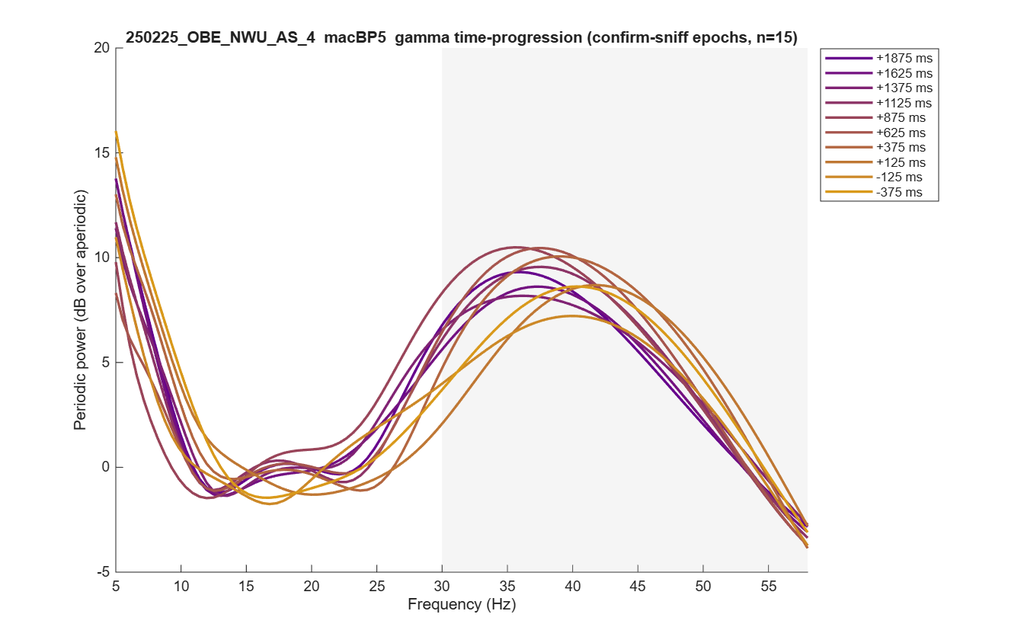

### 6.2 Participants with a detectable gamma peak, per epoch and sniff type

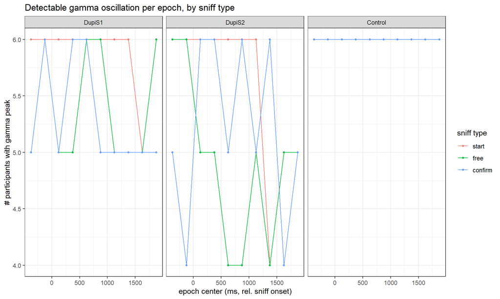

### 6.3 Channel-centered gamma peak frequency across epochs

Group average (red) with each participant shown as lighter connected dots; rows = sniff type, columns = group.

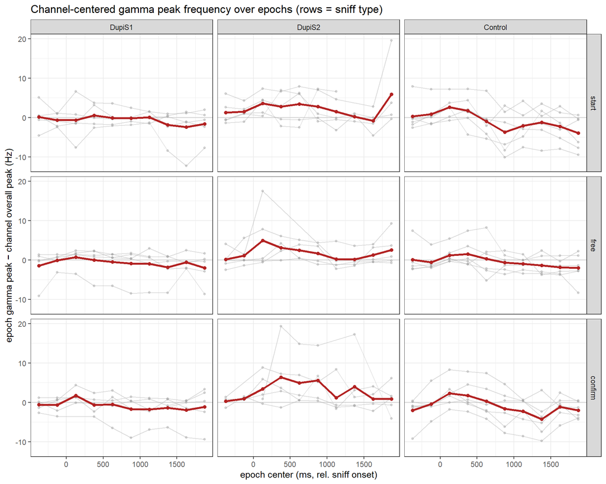

### 6.4 Does gamma peak frequency change over epochs? (LME per group × sniff type)

Linear mixed-effects model `gammaPeakFreq ~ epoch + (1|subject)`, fit within each group × sniff type; epochs with no FOOOF-detected gamma peak are treated as missing.

LME: gamma peak freq ~ epoch + (1|subject), per group × sniff type (slope = Hz / 250 ms epoch).

| group | locking | n_obs | n_subj | slope_Hz_per_epoch | SE | t | p |
| --- | --- | --- | --- | --- | --- | --- | --- |
| DupiS1 | start | 58 | 6 | -0.2699 | 0.1401 | -1.9270 | 0.0596 |
| DupiS2 | start | 56 | 6 | -0.0978 | 0.1788 | -0.5472 | 0.5867 |
| Control | start | 60 | 6 | -0.5692 | 0.1190 | -4.7841 | 0.0000 |
| DupiS1 | free | 54 | 6 | -0.1049 | 0.0743 | -1.4123 | 0.1644 |
| DupiS2 | free | 49 | 6 | 0.0182 | 0.1544 | 0.1181 | 0.9065 |
| Control | free | 60 | 6 | -0.2950 | 0.0856 | -3.4467 | 0.0011 |
| DupiS1 | confirm | 53 | 6 | -0.1870 | 0.0875 | -2.1372 | 0.0379 |
| DupiS2 | confirm | 52 | 6 | -0.1115 | 0.1900 | -0.5867 | 0.5603 |
| Control | confirm | 60 | 6 | -0.3153 | 0.1137 | -2.7725 | 0.0077 |

### 6.5 Does gamma frequency track gamma power across epochs?

Each epoch’s gamma peak is expressed **relative to the channel’s whole-recording (overall) FOOOF peak** (§3) by **subtraction**: Δfreq = epoch peak − overall peak (Hz; interval-scaled), and Δpower = epoch peak height − overall peak height (`gammaPeakPower` is the FOOOF peak height above the 1/f aperiodic, log10 power ≈ dB/10, already SNR-corrected). Dots are session×epoch, colored by epoch (ochre→purple); rows = sniff type, columns = group; the grey line is a pooled fit (orientation only). The table is the proper **within-session** test, per group × sniff type.

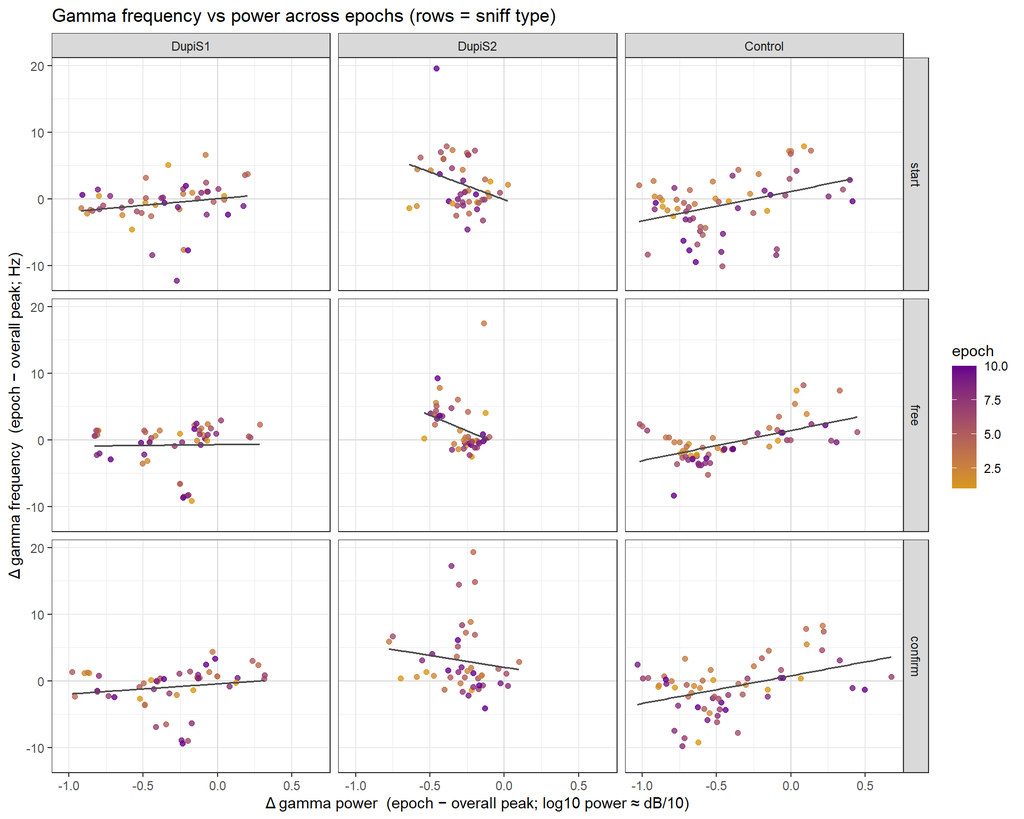

Within-session LME: Δfreq ~ Δpower + (Δpower|session), per group × sniff type.

| group | locking | n_obs | n_subj | model | slope_Hz_per_logPow | SE | t | p |
| --- | --- | --- | --- | --- | --- | --- | --- | --- |
| DupiS1 | start | 50 | 5 | rand.slope | -3.5685 | 4.1642 | -0.8569 | 0.4527 |
| DupiS2 | start | 46 | 5 | rand.slope | -6.7004 | 4.9178 | -1.3625 | 0.2385 |
| Control | start | 60 | 6 | rand.slope | -6.4536 | 2.2372 | -2.8847 | 0.1115 |
| DupiS1 | free | 50 | 5 | rand.slope | -8.5274 | 5.6151 | -1.5187 | 0.2528 |
| DupiS2 | free | 45 | 5 | rand.intercept | -6.4850 | 5.8715 | -1.1045 | 0.2805 |
| Control | free | 60 | 6 | rand.slope | -5.8029 | 2.9960 | -1.9369 | 0.1641 |
| DupiS1 | confirm | 49 | 5 | rand.intercept | -3.9994 | 1.7869 | -2.2382 | 0.0301 |
| DupiS2 | confirm | 45 | 5 | rand.slope | -12.2174 | 15.4664 | -0.7899 | 0.4822 |
| Control | confirm | 60 | 6 | rand.slope | -2.9698 | 2.1850 | -1.3592 | 0.1886 |